# Métodos computacionais para análise de risco

25 de março de 2018

## BANCO DE DADOS USPRIVAUTOCLAIM

Este banco de dados mostra reclamos de seguros de automóveis de um seguradora nos EUA. As reivindicações que não foram fechadas até o final do ano são excluídas. Além disso, uma classifição de risco está disponível e é baseada nas características do motorista e do veículo.

```
## 'data.frame':    6773 obs. of  5 variables:
##  $ STATE : Factor w/ 13 levels "STATE 01","STATE 02",..: 11 12 12 12 12 12 12 7 11 3 ...
##  $ CLASS : Factor w/ 18 levels "C1 ","C11","C1A",..: 7 7 2 16 16 16 2 7 2 2 ...
##  $ GENDER: Factor w/ 2 levels "F","M": 2 2 2 1 2 2 2 2 2 2 ...
##  $ AGE   : int  97 96 95 95 95 95 94 94 93 93 ...
##  $ PAID  : num  1134 3761 7842 2385 650 ...
```

## Medidas da variável PAID (Valor das indenizações pagas)

```
##    Min. 1st Qu.  Median    Mean 3rd Qu.    Max.
##     9.5   523.7  1001.7  1853.0  2137.4 60000.0
```

## Distribuição da variável PAID

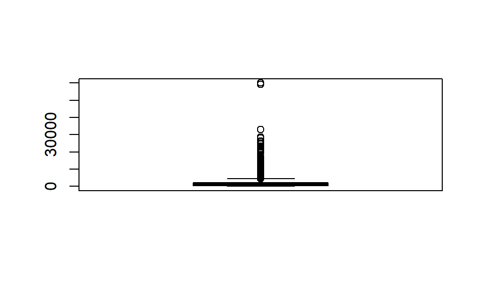

## 1. Distribuição da variável PAID

Após transformar a variável em log, observa-se uma melhor simetria dos valores observados. Nota-se uma melhora na variância, porém ainda não parece ser constante a medida que nos afastamos dos quartis dois e três.

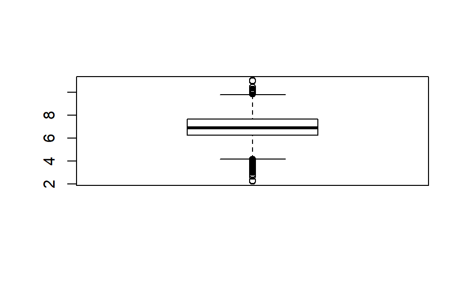

## Distribuição da variável PAID

Nota-se uma assimetria na distribuição do valor das indenizações.

[figure not shown]

## Distribuição da variável PAID

Ao fazermos a transformação da variável para log, consegue-se observar uma distribuição parecida com a Normal, podendo vir a sugerir que essa variável segue essa distruibuição.

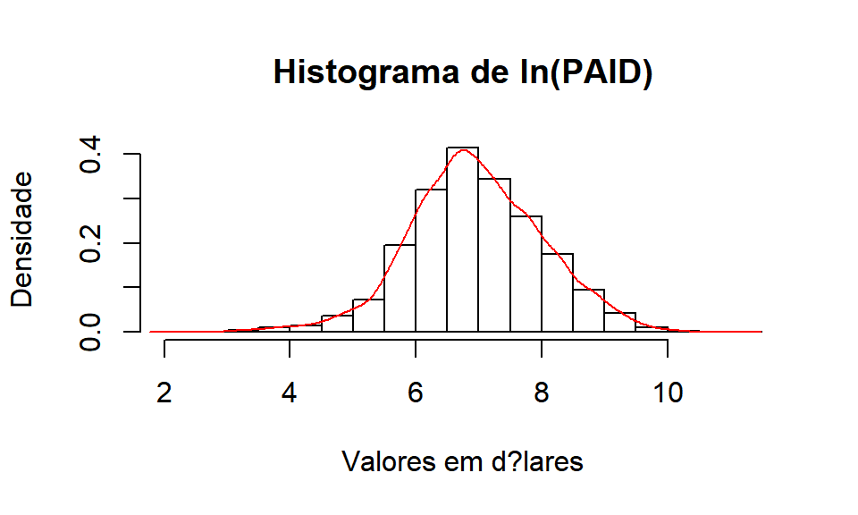

## 3. Distribuição variável AGE

```
##    Min. 1st Qu.  Median    Mean 3rd Qu.    Max.
##   50.00   54.00   62.00   63.81   72.00   97.00
```

## 3. Distribuição variável AGE

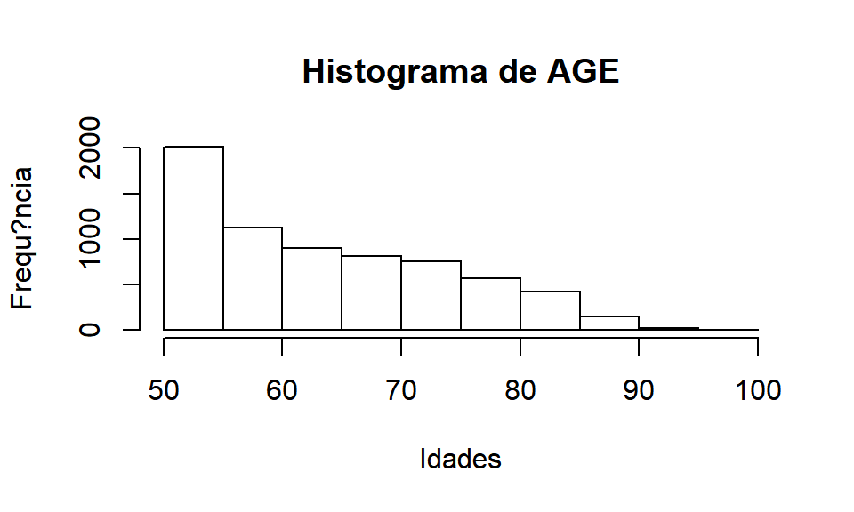

## 3. Distribuição variável AGE

A melhor transformação encontrada foi: 1/sqrt(AGE):

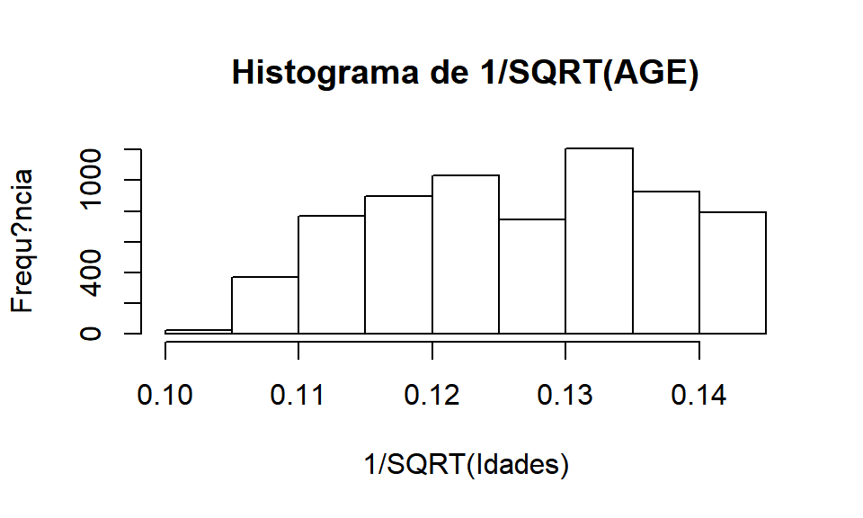

## 3. Distribuição variável AGE

Medidas da variável AGE transformada:

```
##    Min. 1st Qu.  Median    Mean 3rd Qu.    Max.
##  0.1015  0.1179  0.1270  0.1265  0.1361  0.1414
```

## 3. Distribuição variável AGE

Coeficiente de variação. Interpretando tal coeficiente, pode-se afirmar que, em média, os desvios atingem em relação à média 8,063% do valor desta.

```
## [1] 8.06332
```

## 4. Descrição variáveis categóricas

O restante das variáveis do banco são todas categóricas

## 4.1. Variável STATE

Existem 13 estados distintos.

Há diferenças entre o número de indenizações e o estado de ocorrência. Certamente, há variáveis implícitas por trás de cada categoria de estado - número de expostos na apólice, número de motoristas habilitados, tamanho da população, idade para habilitação, etc. - que podem influenciar no número de indenizações.

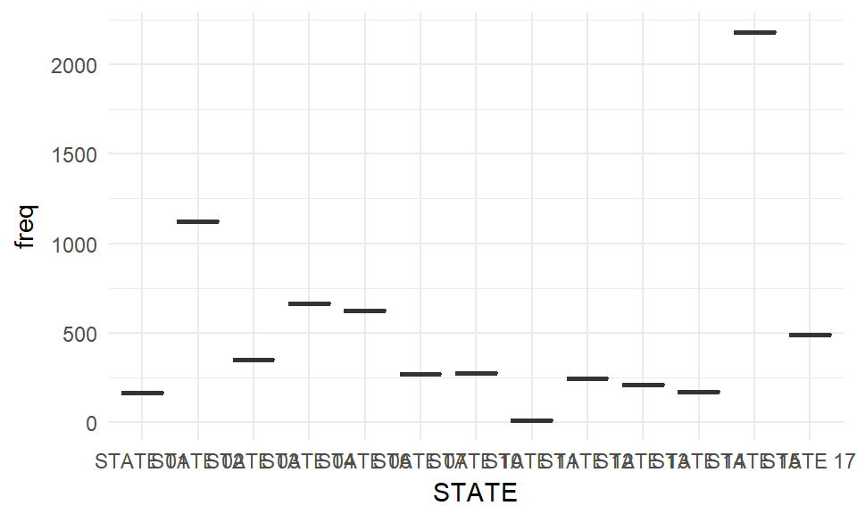

## 4.2. CLASS

```
##    CLASS freq
## 1    C1   726
## 2    C11 1151
## 3    C1A   77
## 4    C1B  424
## 5    C1C   38
## 6    C2    61
## 7    C6   911
## 8    C7   913
## 9    C71 1129
## 10   C72   85
## 11   C7A  113
## 12   C7B  686
## 13   C7C   81
## 14   F1    29
## 15   F11   40
## 16   F6   157
## 17   F7    59
## 18   F71   93
```

```
##    CLASS freq
## 2    C11 1151
## 9    C71 1129
## 8    C7   913
## 7    C6   911
## 1    C1   726
## 12   C7B  686
## 4    C1B  424
## 16   F6   157
## 11   C7A  113
## 18   F71   93
## 10   C72   85
## 13   C7C   81
## 3    C1A   77
## 6    C2    61
## 17   F7    59
## 15   F11   40
## 5    C1C   38
## 14   F1    29
```

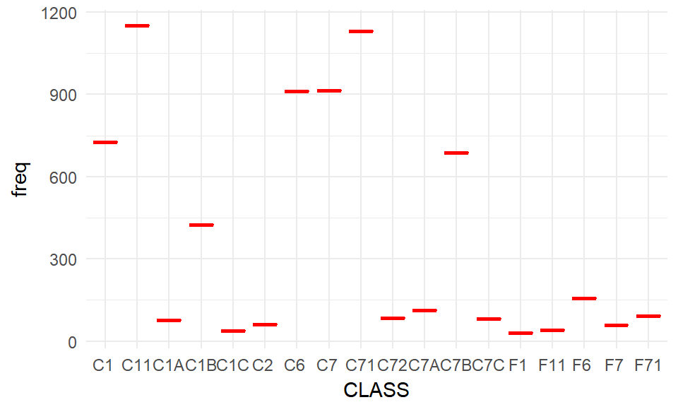

## 4.3. GENDER

```
##   GENDER freq
## 1      F 2582
## 2      M 4191
```

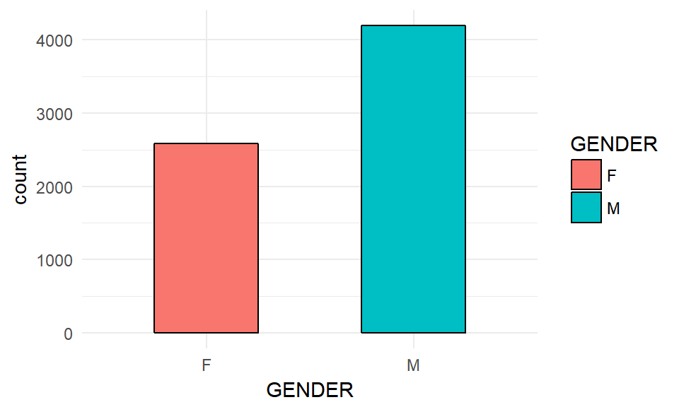

## 5. ANÁLISE MULTIVARIADA

5.1. Análise ln(PAID) com AGE

[figure not shown]

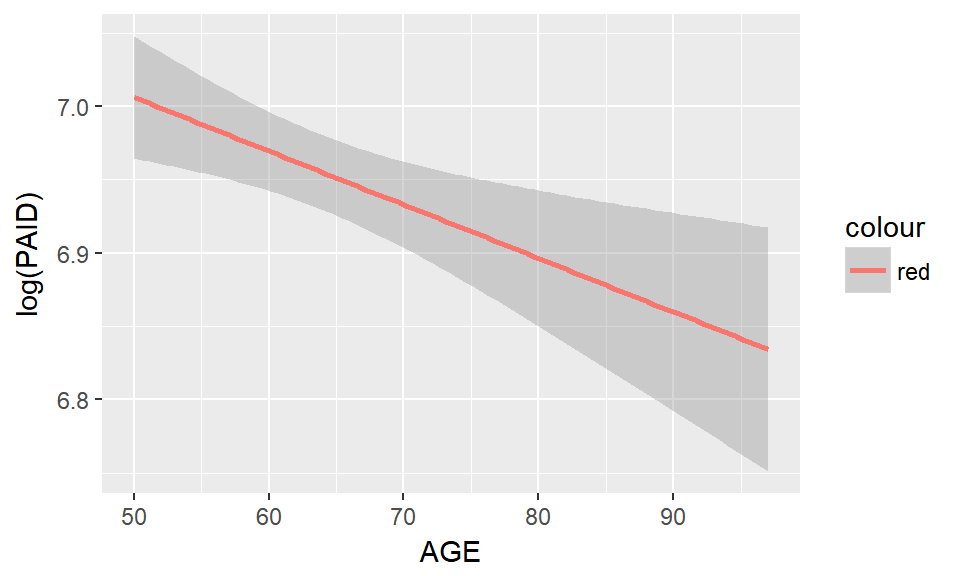

## 5. ANÁLISE MULTIVARIADA

5.1. Análise ln(PAID) com AGE

Valores dos resíduos são bem consideráveis; coeficiente pra idade deu significativo (valor p < 5%), porém, pelo R² e R² ajustado, o modelo não explica nada da variabilidade.

```
##
## Call:
## lm(formula = log(usprivautoclaim$PAID) ~ usprivautoclaim$AGE)
##
## Residuals:
##     Min      1Q  Median      3Q     Max
## -4.7475 -0.6927 -0.0431  0.7101  4.1238
##
## Coefficients:
##                      Estimate Std. Error t value Pr(>|t|)
## (Intercept)          7.189060   0.078865  91.157   <2e-16 ***
## usprivautoclaim$AGE -0.003658   0.001219  -3.001   0.0027 **
## ---
## Signif. codes:  0 '***' 0.001 '**' 0.01 '*' 0.05 '.' 0.1 ' ' 1
##
## Residual standard error: 1.07 on 6771 degrees of freedom
## Multiple R-squared:  0.001329,   Adjusted R-squared:  0.001181
## F-statistic: 9.007 on 1 and 6771 DF,  p-value: 0.002699
```

## 5. ANÁLISE MULTIVARIADA

5.2. Análise ln(PAID) com 1/sqrt(AGE)

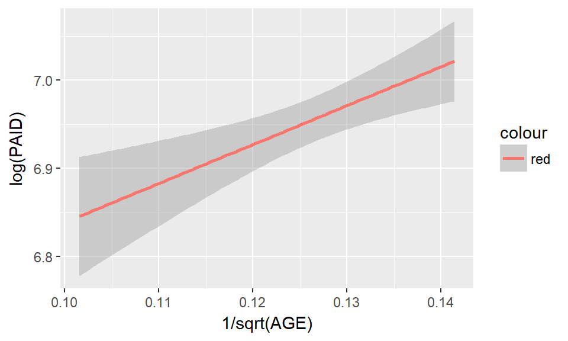

## 5. ANÁLISE MULTIVARIADA

5.2. Análise ln(PAID) com 1/sqrt(AGE)

Variância não é constante ao longo da variável resposta -> necessidade de usar um modelo do tipo “weighted least square”.

```
##
## Call:
## lm(formula = log(PAID) ~ (TRAGE), data = usprivautoclaim)
##
## Residuals:
##     Min      1Q  Median      3Q     Max
## -4.7582 -0.6908 -0.0423  0.7093  4.1218
##
## Coefficients:
##             Estimate Std. Error t value Pr(>|t|)
## (Intercept)   6.3979     0.1618  39.541  < 2e-16 ***
## TRAGE         4.4106     1.2754   3.458 0.000547 ***
## ---
## Signif. codes:  0 '***' 0.001 '**' 0.01 '*' 0.05 '.' 0.1 ' ' 1
##
## Residual standard error: 1.07 on 6771 degrees of freedom
## Multiple R-squared:  0.001763,   Adjusted R-squared:  0.001616
## F-statistic: 11.96 on 1 and 6771 DF,  p-value: 0.0005472
```

## 5. ANÁLISE MULTIVARIADA

5.2. Análise ln(PAID) com 1/sqrt(AGE)

Melhorou o ajuste e os resíduos são menores e mais bem comportados.

```
##
## Call:
## lm(formula = log(PAID) ~ (TRAGE), data = usprivautoclaim, weights = 1/AGE^3)
##
## Weighted Residuals:
##        Min         1Q     Median         3Q        Max
## -0.0127389 -0.0013369 -0.0000691  0.0013833  0.0079910
##
## Coefficients:
##             Estimate Std. Error t value Pr(>|t|)
## (Intercept)    6.148      0.186  33.045  < 2e-16 ***
## TRAGE          6.349      1.417   4.479 7.62e-06 ***
## ---
## Signif. codes:  0 '***' 0.001 '**' 0.01 '*' 0.05 '.' 0.1 ' ' 1
##
## Residual standard error: 0.002234 on 6771 degrees of freedom
## Multiple R-squared:  0.002954,   Adjusted R-squared:  0.002807
## F-statistic: 20.06 on 1 and 6771 DF,  p-value: 7.62e-06
```

## 5. ANÁLISE MULTIVARIADA

5.3. LN(PAID) com STATE

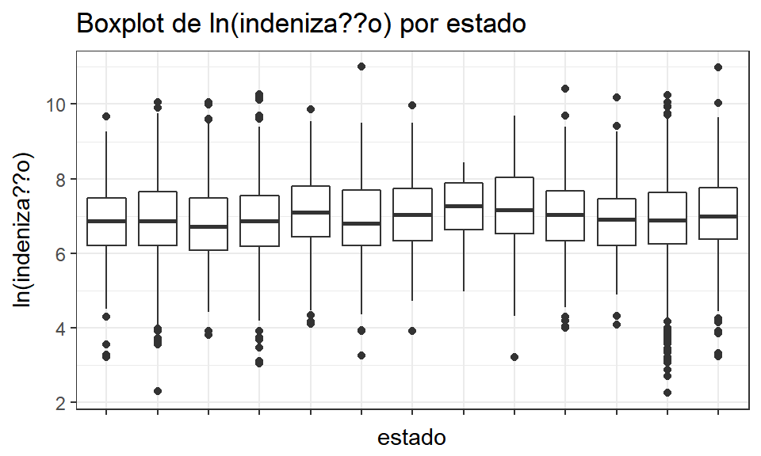

## 5. ANÁLISE MULTIVARIADA

5.3. LN(PAID) com STATE

Rejeita-se h0: não consideramos as médias entre os grupos iguais

```
##
##  One-way analysis of means (not assuming equal variances)
##
## data:  log(PAID) and STATE
## F = 4.5546, num df = 12.00, denom df = 352.44, p-value = 7.538e-07
```

## 5. ANÁLISE MULTIVARIADA

5.4. LN(PAID) com CLASS

```
## 'data.frame':    6773 obs. of  7 variables:
##  $ STATE : Factor w/ 13 levels "STATE 01","STATE 02",..: 11 12 12 12 12 12 12 7 11 3 ...
##  $ CLASS : Factor w/ 18 levels "C1 ","C11","C1A",..: 7 7 2 16 16 16 2 7 2 2 ...
##  $ GENDER: Factor w/ 2 levels "F","M": 2 2 2 1 2 2 2 2 2 2 ...
##  $ AGE   : int  97 96 95 95 95 95 94 94 93 93 ...
##  $ PAID  : num  1134 3761 7842 2385 650 ...
##  $ TRAGE : num  0.102 0.102 0.103 0.103 0.103 ...
##  $ lnPAID: num  7.03 8.23 8.97 7.78 6.48 ...
```

## 5. ANÁLISE MULTIVARIADA

5.4. LN(PAID) com CLASS

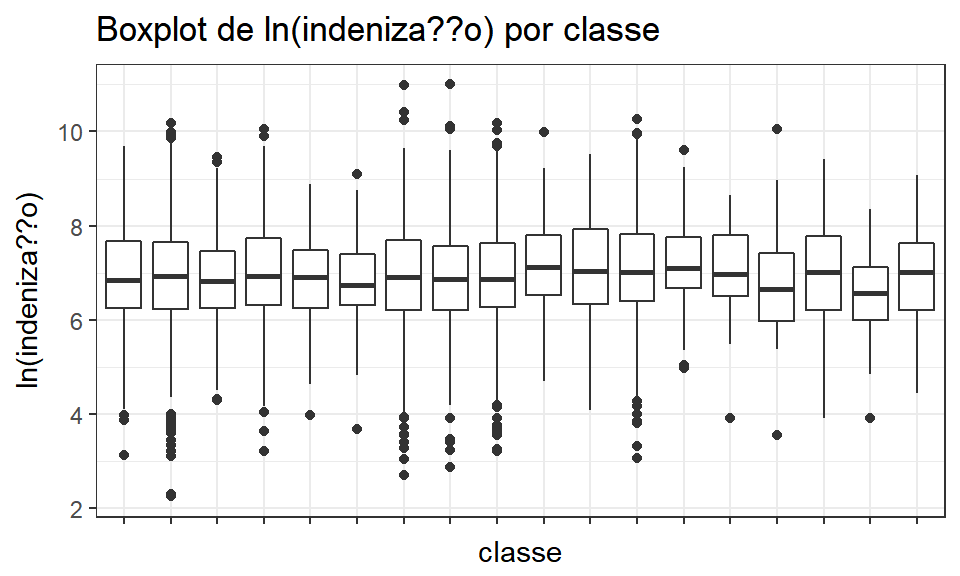

## 5. ANÁLISE MULTIVARIADA

5.4. LN(PAID) com CLASS

Rejeita-se h0: não consideramos as médias entre os grupos iguais

```
##
##  One-way analysis of means (not assuming equal variances)
##
## data:  log(PAID) and CLASS
## F = 2.2757, num df = 17.00, denom df = 567.51, p-value = 0.002524
```

## 5. ANÁLISE MULTIVARIADA

5.5. LN(PAID) com GENDER

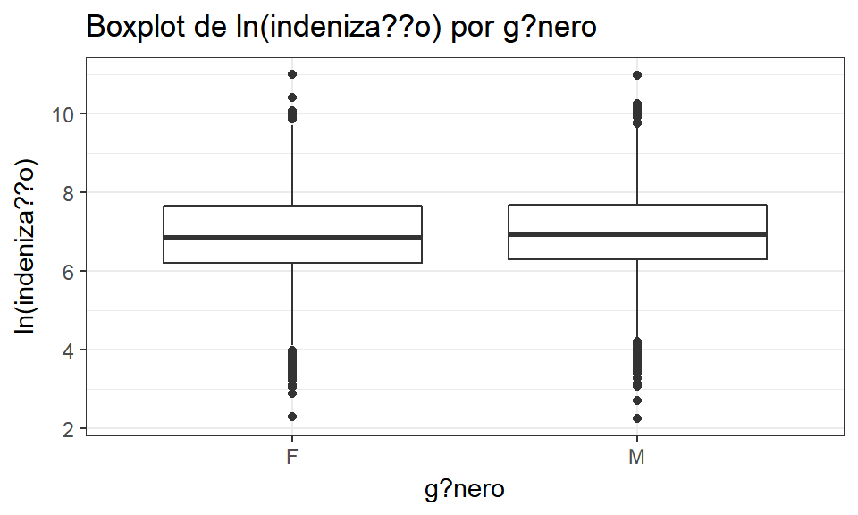

## 5. ANÁLISE MULTIVARIADA

5.5. LN(PAID) com GENDER

```
##
##  One-way analysis of means (not assuming equal variances)
##
## data:  log(PAID) and GENDER
## F = 1.894, num df = 1.0, denom df = 5311.2, p-value = 0.1688
```

## AJUSTANDO O MODELO

Modelo não ficou muito bem ajustado, sem muitas coisas explicaticas.

Vários níveis das variáveis categóricas não significativos estatisticamente.

```
##
## Call:
## lm(formula = log(PAID) ~ (TRAGE) + CLASS + STATE, data = usprivautoclaim,
##     weights = 1/AGE^3)
##
## Weighted Residuals:
##        Min         1Q     Median         3Q        Max
## -0.0126540 -0.0013235 -0.0000756  0.0013803  0.0080985
##
## Coefficients:
##                Estimate Std. Error t value Pr(>|t|)
## (Intercept)    6.012401   0.249419  24.106  < 2e-16 ***
## TRAGE          6.169402   1.773663   3.478 0.000508 ***
## CLASSC11       0.093411   0.052189   1.790 0.073518 .
## CLASSC1A      -0.109576   0.114394  -0.958 0.338156
## CLASSC1B       0.018866   0.060338   0.313 0.754533
## CLASSC1C      -0.184708   0.151961  -1.215 0.224219
## CLASSC2       -0.122492   0.128904  -0.950 0.342013
## CLASSC6        0.108565   0.069854   1.554 0.120192
## CLASSC7       -0.008901   0.052233  -0.170 0.864697
## CLASSC71       0.042774   0.050515   0.847 0.397153
## CLASSC72       0.284897   0.112685   2.528 0.011486 *
## CLASSC7A       0.123792   0.099949   1.239 0.215556
## CLASSC7B       0.116060   0.054273   2.138 0.032515 *
## CLASSC7C       0.314571   0.107509   2.926 0.003445 **
## CLASSF1        0.185541   0.215281   0.862 0.388796
## CLASSF11      -0.048863   0.201983  -0.242 0.808854
## CLASSF6        0.108136   0.133607   0.809 0.418339
## CLASSF7       -0.273921   0.140525  -1.949 0.051305 .
## CLASSF71       0.043118   0.111860   0.385 0.699908
## STATESTATE 02  0.102529   0.090704   1.130 0.258361
## STATESTATE 03 -0.026332   0.101659  -0.259 0.795629
## STATESTATE 04  0.038114   0.095109   0.401 0.688627
## STATESTATE 06  0.242032   0.094326   2.566 0.010312 *
## STATESTATE 07  0.086726   0.106841   0.812 0.416974
## STATESTATE 10  0.212950   0.104665   2.035 0.041931 *
## STATESTATE 11  0.243961   0.345123   0.707 0.479663
## STATESTATE 12  0.378273   0.107526   3.518 0.000438 ***
## STATESTATE 13  0.198350   0.108830   1.823 0.068413 .
## STATESTATE 14  0.125477   0.119041   1.054 0.291890
## STATESTATE 15  0.034882   0.088443   0.394 0.693294
## STATESTATE 17  0.198161   0.098332   2.015 0.043921 *
## ---
## Signif. codes:  0 '***' 0.001 '**' 0.01 '*' 0.05 '.' 0.1 ' ' 1
##
## Residual standard error: 0.002223 on 6742 degrees of freedom
## Multiple R-squared:  0.01643,    Adjusted R-squared:  0.01205
## F-statistic: 3.754 on 30 and 6742 DF,  p-value: 2.227e-11
```

## Modelo apenas com a variável TRAGE

```
##
## Call:
## lm(formula = log(PAID) ~ (TRAGE), data = usprivautoclaim, weights = 1/AGE^3)
##
## Coefficients:
## (Intercept)        TRAGE
##       6.148        6.349
```

```
##
## Call:
## lm(formula = log(PAID) ~ (TRAGE), data = usprivautoclaim, weights = 1/AGE^3)
##
## Weighted Residuals:
##        Min         1Q     Median         3Q        Max
## -0.0127389 -0.0013369 -0.0000691  0.0013833  0.0079910
##
## Coefficients:
##             Estimate Std. Error t value Pr(>|t|)
## (Intercept)    6.148      0.186  33.045  < 2e-16 ***
## TRAGE          6.349      1.417   4.479 7.62e-06 ***
## ---
## Signif. codes:  0 '***' 0.001 '**' 0.01 '*' 0.05 '.' 0.1 ' ' 1
##
## Residual standard error: 0.002234 on 6771 degrees of freedom
## Multiple R-squared:  0.002954,   Adjusted R-squared:  0.002807
## F-statistic: 20.06 on 1 and 6771 DF,  p-value: 7.62e-06
```

## Modelo considerando apenas vari?ál STATE

Modelo considerando apenas variável STATE

```
##
## Call:
## lm(formula = log(PAID) ~ (STATE), data = usprivautoclaim, weights = 1/AGE^3)
##
## Weighted Residuals:
##        Min         1Q     Median         3Q        Max
## -0.0124068 -0.0013807 -0.0001207  0.0013374  0.0081065
##
## Coefficients:
##                Estimate Std. Error t value Pr(>|t|)
## (Intercept)    6.843121   0.084777  80.719  < 2e-16 ***
## STATESTATE 02  0.127651   0.090352   1.413 0.157752
## STATESTATE 03 -0.001797   0.101620  -0.018 0.985891
## STATESTATE 04  0.078327   0.094104   0.832 0.405244
## STATESTATE 06  0.271520   0.093766   2.896 0.003795 **
## STATESTATE 07  0.122715   0.105945   1.158 0.246788
## STATESTATE 10  0.254963   0.104280   2.445 0.014512 *
## STATESTATE 11  0.253308   0.344973   0.734 0.462802
## STATESTATE 12  0.404680   0.106471   3.801 0.000145 ***
## STATESTATE 13  0.238233   0.108167   2.202 0.027666 *
## STATESTATE 14  0.127671   0.119022   1.073 0.283461
## STATESTATE 15  0.060429   0.087928   0.687 0.491947
## STATESTATE 17  0.235092   0.097329   2.415 0.015742 *
## ---
## Signif. codes:  0 '***' 0.001 '**' 0.01 '*' 0.05 '.' 0.1 ' ' 1
##
## Residual standard error: 0.002229 on 6760 degrees of freedom
## Multiple R-squared:  0.008892,   Adjusted R-squared:  0.007132
## F-statistic: 5.054 on 12 and 6760 DF,  p-value: 1.891e-08
```

## Modelo considerando apenas variável AGE

```
##
## Call:
## lm(formula = log(PAID) ~ (AGE), data = usprivautoclaim, weights = 1/AGE^3)
##
## Weighted Residuals:
##        Min         1Q     Median         3Q        Max
## -0.0127217 -0.0013394 -0.0000714  0.0013815  0.0079955
##
## Coefficients:
##              Estimate Std. Error t value Pr(>|t|)
## (Intercept)  7.327975   0.085433  85.774  < 2e-16 ***
## AGE         -0.005891   0.001426  -4.132 3.65e-05 ***
## ---
## Signif. codes:  0 '***' 0.001 '**' 0.01 '*' 0.05 '.' 0.1 ' ' 1
##
## Residual standard error: 0.002234 on 6771 degrees of freedom
## Multiple R-squared:  0.002515,   Adjusted R-squared:  0.002367
## F-statistic: 17.07 on 1 and 6771 DF,  p-value: 3.646e-05
```

## Diferença entre os modelos

```
## Analysis of Variance Table
##
## Model 1: log(PAID) ~ (TRAGE) + CLASS + STATE
## Model 2: log(PAID) ~ (TRAGE)
## Model 3: log(PAID) ~ (STATE)
## Model 4: log(PAID) ~ (AGE)
##   Res.Df      RSS  Df   Sum of Sq      F    Pr(>F)
## 1   6742 0.033324
## 2   6771 0.033780 -29 -0.00045658 3.1853 1.831e-08 ***
## 3   6760 0.033579  11  0.00020117 3.7000 2.818e-05 ***
## 4   6771 0.033795 -11 -0.00021606 3.9739 8.535e-06 ***
## ---
## Signif. codes:  0 '***' 0.001 '**' 0.01 '*' 0.05 '.' 0.1 ' ' 1
```

## Gráfico dos Resíduos

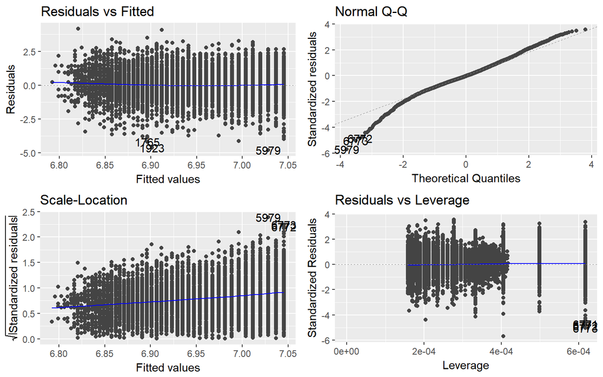

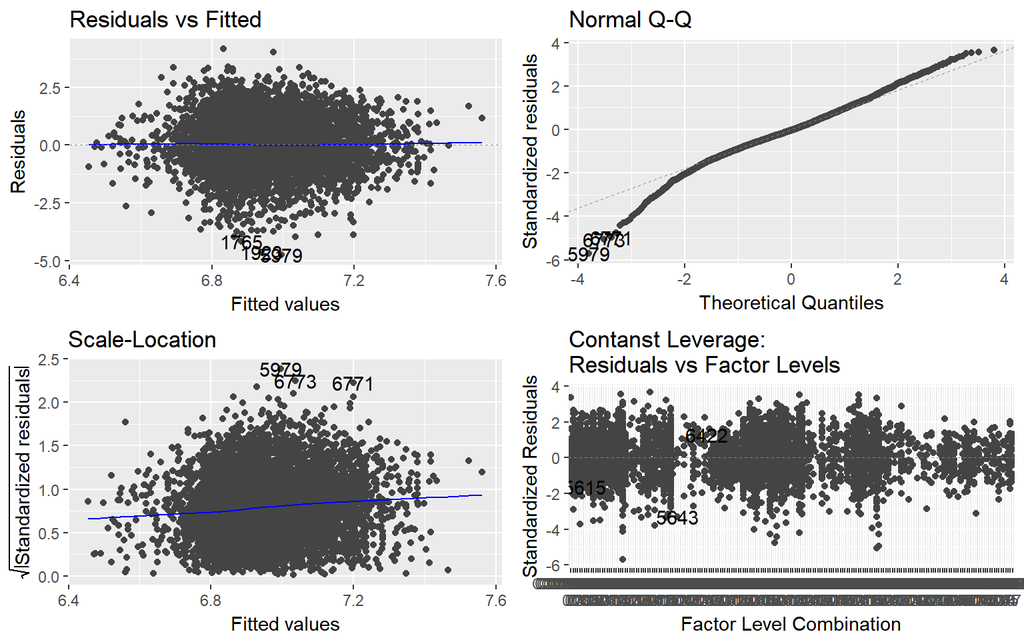